# Paper Example 1b: Model misspecification (generate 2PL, fit 1PL)

This vignette extends the linked-design example from Schroeders and Gnambs (2025) by asking: **what happens to item difficulty recovery when the fitted model is misspecified?** Data are generated under a 2PL with substantially variable discriminations, then fitted under both the correct 2PL and a misspecified 1PL (Rasch). For the faithful paper reproduction, see `vignette("paper-example-1-linked-design")`.

## Background

The Rasch model assumes equal discrimination across items. When this assumption is violated, item difficulty estimates absorb the discrimination heterogeneity. The misspecification creates a bias-variance tradeoff: the 1PL estimates fewer parameters per item (no `a`), so each `b` estimate has lower sampling variance — but the constraint introduces persistent bias that does not shrink with N.

We generate a 20-item test with discriminations drawn from a lognormal distribution with substantial variability (`a_mean = 0.2`, `a_sd = 0.5` on the log scale), producing a realistic range of discriminations (roughly 0.5 to 2.5).

## Study Design

```r
library(irtsim)

set.seed(2024)
n_items <- 20

params <- irt_params_2pl(
  n_items = n_items, a_dist = "lnorm",
  a_mean = 0.2, a_sd = 0.5,
  b_mean = 0, b_sd = 1, seed = 2024
)

design <- irt_design(
  model = "2PL", n_items = n_items,
  item_params = params, theta_dist = "normal"
)

sample_sizes <- seq(200, 1000, by = 200)

study_correct <- irt_study(design, sample_sizes = sample_sizes)
study_misspec <- irt_study(design, sample_sizes = sample_sizes,
                           estimation_model = "1PL")

res_correct <- irt_simulate(study_correct, iterations = 500,
                            seed = 2024, parallel = TRUE)
res_misspec <- irt_simulate(study_misspec, iterations = 500,
                            seed = 2024, parallel = TRUE)
```

> **Note on reproducibility.** Precomputed with `parallel = TRUE`. See `?irt_simulate` for the serial/parallel reproducibility contract.

## Proportion of Items Meeting RMSE Threshold

The key question is not “what is the max recommended N” but “at each sample size, what fraction of items have acceptable RMSE?” This captures both items that converge quickly and items that never converge.

```r
#' Compute proportion of items meeting a criterion threshold at each N
prop_meeting <- function(res, criterion, threshold, param = NULL) {
  s <- summary(res, criterion = criterion, param = param)
  df <- s$item_summary
  cfg <- irtsim:::get_criterion_config(criterion)
  vals <- df[[criterion]]
  if (cfg$use_abs) vals <- abs(vals)
  if (cfg$direction == "higher_is_better") {
    df$meets <- !is.na(vals) & vals >= threshold
  } else {
    df$meets <- !is.na(vals) & vals <= threshold
  }
  agg <- aggregate(meets ~ sample_size, data = df,
                   FUN = function(x) mean(x))
  names(agg)[2] <- "prop_meeting"
  agg
}
```

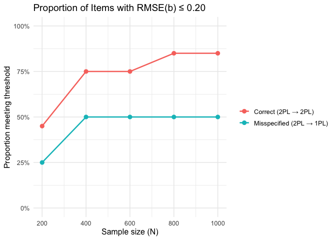

```r
prop_correct <- prop_meeting(res_correct, "rmse", 0.20, param = "b")
prop_correct$model <- "Correct (2PL \u2192 2PL)"

prop_misspec <- prop_meeting(res_misspec, "rmse", 0.20, param = "b")
prop_misspec$model <- "Misspecified (2PL \u2192 1PL)"

prop_df <- rbind(prop_correct, prop_misspec)

ggplot(prop_df, aes(x = sample_size, y = prop_meeting, colour = model)) +
  geom_line(linewidth = 0.9) +
  geom_point(size = 2.5) +
  scale_y_continuous(labels = scales::percent_format(), limits = c(0, 1)) +
  labs(
    title = "Proportion of Items with RMSE(b) \u2264 0.20",
    x = "Sample size (N)", y = "Proportion meeting threshold",
    colour = NULL
  ) +
  theme_minimal(base_size = 12)
```

## Aggregate RMSE Trajectory

The ribbon shows the range (min to max) across items; the line is the mean.

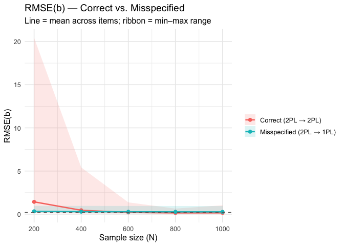

```r
make_agg <- function(res, param, label) {
  s <- summary(res, criterion = "rmse", param = param)
  agg <- aggregate(rmse ~ sample_size, data = s$item_summary,
    FUN = function(x) c(mean = mean(x), min = min(x), max = max(x)))
  agg <- do.call(data.frame, agg)
  names(agg) <- c("sample_size", "mean_rmse", "min_rmse", "max_rmse")
  agg$model <- label
  agg
}

agg <- rbind(
  make_agg(res_correct, "b", "Correct (2PL \u2192 2PL)"),
  make_agg(res_misspec, "b", "Misspecified (2PL \u2192 1PL)")
)

ggplot(agg, aes(x = sample_size, colour = model, fill = model)) +
  geom_ribbon(aes(ymin = min_rmse, ymax = max_rmse), alpha = 0.15, colour = NA) +
  geom_line(aes(y = mean_rmse), linewidth = 0.9) +
  geom_point(aes(y = mean_rmse), size = 2) +
  geom_hline(yintercept = 0.20, linetype = "dashed", colour = "grey40") +
  labs(
    title = "RMSE(b) — Correct vs. Misspecified",
    subtitle = "Line = mean across items; ribbon = min\u2013max range",
    x = "Sample size (N)", y = "RMSE(b)", colour = NULL, fill = NULL
  ) +
  theme_minimal(base_size = 12)
```

## Bias — The Persistent Cost

RMSE alone can hide a critical difference between models: misspecification introduces **persistent bias** that does not shrink with N. This is the Rasch model’s fundamental limitation when discriminations are unequal — the bias is structural, not sampling error.

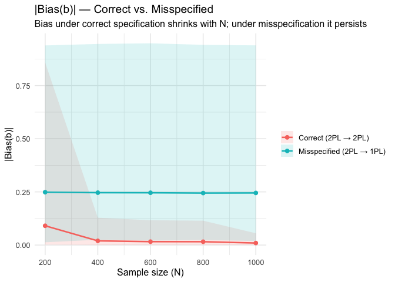

```r
make_agg_bias <- function(res, param, label) {
  s <- summary(res, criterion = "bias", param = param)
  s$item_summary$abs_bias <- abs(s$item_summary$bias)
  agg <- aggregate(abs_bias ~ sample_size, data = s$item_summary,
    FUN = function(x) c(mean = mean(x), min = min(x), max = max(x)))
  agg <- do.call(data.frame, agg)
  names(agg) <- c("sample_size", "mean_absbias", "min_absbias", "max_absbias")
  agg$model <- label
  agg
}

agg_b <- rbind(
  make_agg_bias(res_correct, "b", "Correct (2PL \u2192 2PL)"),
  make_agg_bias(res_misspec, "b", "Misspecified (2PL \u2192 1PL)")
)

ggplot(agg_b, aes(x = sample_size, colour = model, fill = model)) +
  geom_ribbon(aes(ymin = min_absbias, ymax = max_absbias), alpha = 0.15, colour = NA) +
  geom_line(aes(y = mean_absbias), linewidth = 0.9) +
  geom_point(aes(y = mean_absbias), size = 2) +
  labs(
    title = "|Bias(b)| — Correct vs. Misspecified",
    subtitle = "Bias under correct specification shrinks with N; under misspecification it persists",
    x = "Sample size (N)", y = "|Bias(b)|", colour = NULL, fill = NULL
  ) +
  theme_minimal(base_size = 12)
```

## Summary

```r
rec_correct <- recommended_n(summary(res_correct, param = "b"),
                             criterion = "rmse", threshold = 0.20, param = "b",
                             aggregate = "none")
rec_misspec <- recommended_n(summary(res_misspec, param = "b"),
                             criterion = "rmse", threshold = 0.20, param = "b",
                             aggregate = "none")

n_items <- nrow(rec_correct)
n_na_correct <- sum(is.na(rec_correct$recommended_n))
n_na_misspec <- sum(is.na(rec_misspec$recommended_n))

cat("Items tested:", n_items, "\n")
```

```
#> Items tested: 20
```

```r
cat("Items reaching RMSE(b) <= 0.20:\n")
```

```
#> Items reaching RMSE(b) <= 0.20:
```

```r
cat("  Correct:", n_items - n_na_correct, "of", n_items, "\n")
```

```
#>   Correct: 17 of 20
```

```r
cat("  Misspecified:", n_items - n_na_misspec, "of", n_items, "\n")
```

```
#>   Misspecified: 10 of 20
```

The proportion-meeting-threshold plot captures both sides of this tradeoff in a way that a single `max(recommended_n)` cannot.

## References

Morris, T. P., White, I. R., & Crowther, M. J. (2019). Using simulation studies to evaluate statistical methods. *Statistics in Medicine*, 38(11), 2074–2102.

Schroeders, U., & Gnambs, T. (2025). Sample-size planning in item response theory: A tutorial. *Advances in Methods and Practices in Psychological Science*, 8(1).